# Retained intron analysis with suppa

We generated percent spliced in (PSI) or $\Psi$ numbers for each sample using suppa. I haven’t used suppa before and it can only pick out retained intron events that appear in the GTF file, not discover new events. There are ~ 5500 events annotated so hopefully this will be enough to see if there are broad changes and pick out a couple of hits.

```r
> load("counts.RData")
```

```r
> suppa = read.table("suppa/ie-events.psi")
> control = rownames(summarydata)[grepl("^control", rownames(summarydata))]
> prpf8 = rownames(summarydata)[grepl("^prpf8", rownames(summarydata))]
> prpf38 = rownames(summarydata)[grepl("^prpf38", rownames(summarydata))]
```

```r
> wc_gene = function(row, x_idx, y_idx) {
+     row[row == -1] = 0
+     row = unlist(as.list(row))
+     xmean = mean(row[x_idx])
+     ymean = mean(row[y_idx])
+     diff = xmean - ymean
+     x = row[x_idx]
+     y = row[y_idx]
+     wt = wilcox.test(x, y)
+     return(data.frame(xmean = xmean, ymean = ymean, diff = diff, W = wt$statistic,
+         pvalue = wt$p.value))
+ }
>
> suppa_test = function(suppa, x_idx, y_idx) {
+     res = apply(suppa, 1, function(x) wc_gene(x, x_idx, y_idx))
+     res.df = data.frame(do.call(rbind, res))
+     res.df$qvalue = p.adjust(res.df$pvalue, method = "BH")
+     return(res.df)
+ }
>
> prpf8_results = suppa_test(suppa, control, prpf8)
> prpf38_results = suppa_test(suppa, control, prpf38)
```

We don’t have enough samples to do a great job with the Wilcoxon rank sum test for each individual event, though we can pick up some differences. We can look at the overall difference in splicing between the samples.

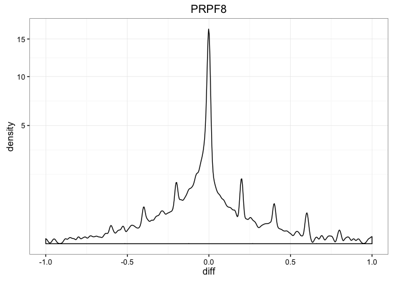

```r
> ggplot(prpf8_results, aes(diff)) + geom_density() + scale_y_sqrt() + theme_bw() +
+     ggtitle("PRPF8")
```

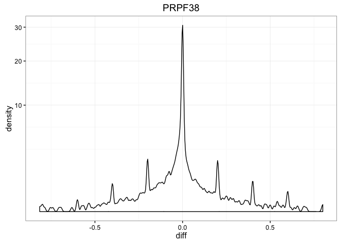

```r
> ggplot(prpf38_results, aes(diff)) + geom_density() + scale_y_sqrt() + theme_bw() +
+     ggtitle("PRPF38")
```

If you squint, there does seem to be an enrichment for higher retained intron events in PRPF8 and PRPF38, there’s a slightly higher negative shoulder. It is not a huge effect though.

Below we test if the difference of (control RI PSI) - (knockout RI PSI) is less than zero (so higher PSI for retained intron events in the knockout samples)

```r
> wilcox.test(prpf38_results$diff, alternative = "less")
```

```
    Wilcoxon signed rank test with continuity correction

data:  prpf38_results$diff
V = 4771100, p-value < 2.2e-16
alternative hypothesis: true location is less than 0
```

```r
> wilcox.test(prpf8_results$diff, alternative = "less")
```

```
    Wilcoxon signed rank test with continuity correction

data:  prpf8_results$diff
V = 4370000, p-value < 2.2e-16
alternative hypothesis: true location is less than 0
```

The event IDs in this table are formatted like [this](https://bitbucket.org/regulatorygenomicsupf/suppa/src)

```
<gene_id>;<event-type>:<seqname>:<coordinates-of-the-event>:<strand>
where:
<gene_id>: is the gene where the even happens
<event-type>: correspond to the two letters code of the event from the following list.
SE: Skipping Exon
A5: Alternative 5' Splice Site
A3: Alternative 3' Splice Site
MX: Mutually Exclusive Exon
RI: Retained Intron
AF: Alternative First Exon
AL: Alternative Last Exon
<seqname>: seqname explained above
<coordinates-of-the-event>: the coordinates of the event depends on the type of event
<strand>: either '+' or '-'
```

# Links to data

PRPF8 retained intron

PRPF38 retained intron

```r
> write.table(prpf8_results, file = "prpf8-RI.csv", sep = ",", quote = FALSE,
+     row.names = TRUE, col.names = TRUE)
> write.table(prpf38_results, file = "prpf38-RI.csv", sep = ",", quote = FALSE,
+     row.names = TRUE, col.names = TRUE)
```